# K-Means

# Mise en place de k-means avec le (k=4) clusters optimaux

```r
#make this example reproducible
set.seed(1)

#perform k-means clustering with k = 4 clusters
km <- kmeans(df, centers = 4, nstart = 25)

#view results
km
```

```
## K-means clustering with 4 clusters of sizes 13, 13, 16, 8
##
## Cluster means:
##       Murder    Assault   UrbanPop        Rape
## 1 -0.9615407 -1.1066010 -0.9301069 -0.96676331
## 2  0.6950701  1.0394414  0.7226370  1.27693964
## 3 -0.4894375 -0.3826001  0.5758298 -0.26165379
## 4  1.4118898  0.8743346 -0.8145211  0.01927104
##
## Clustering vector:
##        Alabama         Alaska        Arizona       Arkansas     California
##              4              2              2              4              2
##       Colorado    Connecticut       Delaware        Florida        Georgia
##              2              3              3              2              4
##         Hawaii          Idaho       Illinois        Indiana           Iowa
##              3              1              2              3              1
##         Kansas       Kentucky      Louisiana          Maine       Maryland
##              3              1              4              1              2
##  Massachusetts       Michigan      Minnesota    Mississippi       Missouri
##              3              2              1              4              2
##        Montana       Nebraska         Nevada  New Hampshire     New Jersey
##              1              1              2              1              3
##     New Mexico       New York North Carolina   North Dakota           Ohio
##              2              2              4              1              3
##       Oklahoma         Oregon   Pennsylvania   Rhode Island South Carolina
##              3              3              3              3              4
##   South Dakota      Tennessee          Texas           Utah        Vermont
##              1              4              2              3              1
##       Virginia     Washington  West Virginia      Wisconsin        Wyoming
##              3              3              1              1              3
##
## Within cluster sum of squares by cluster:
## [1] 11.952463 19.922437 16.212213  8.316061
##  (between_SS / total_SS =  71.2 %)
##
## Available components:
##
## [1] "cluster"      "centers"      "totss"        "withinss"     "tot.withinss"
## [6] "betweenss"    "size"         "iter"         "ifault"
```

Les résultats montrent que:

13 États ont été affectés au deuxième groupe

8 États ont été affectés au quatrième groupe

Nous pouvons visualiser les grappes sur un nuage de points qui affiche les deux premières composantes principales sur les axes à l’aide de la fonction fivz_cluster()

# Visualiser les clusters

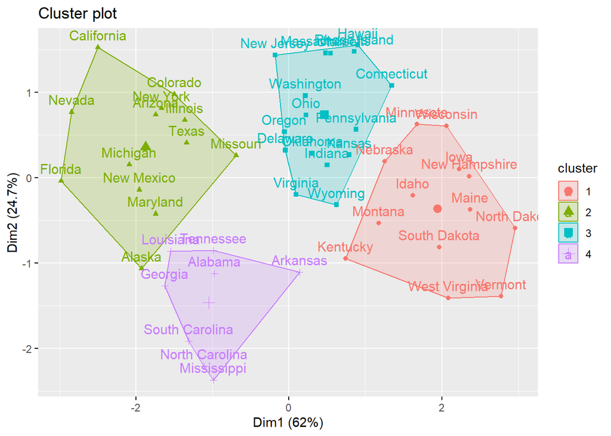

```r
#plot results of final k-means model
fviz_cluster(km, data = df)
```

Nous pouvons également utiliser la fonction aggregate() pour trouver la moyenne des variables dans chaque groupe :

```r
#find means of each cluster
aggregate(USArrests, by=list(cluster=km$cluster), mean)
```

```
##   cluster   Murder   Assault UrbanPop     Rape
## 1       1  3.60000  78.53846 52.07692 12.17692
## 2       2 10.81538 257.38462 76.00000 33.19231
## 3       3  5.65625 138.87500 73.87500 18.78125
## 4       4 13.93750 243.62500 53.75000 21.41250
```

Nous interprétons ce résultat comme suit :

Le nombre moyen de meurtres pour 100 000 habitants dans les États du groupe 1 est de 3,6.

Le nombre moyen d’agressions pour 100 000 citoyens dans les États du groupe 1 est de 78,5.

Le pourcentage moyen de résidents vivant dans une zone urbaine dans les États du groupe 1 est de 52,1 %.

Le nombre moyen de viols pour 100 000 habitants dans les États du groupe 1 est de 12,2.

Et ainsi de suite.

Nous pouvons également ajouter les affectations de grappes de chaque État à l’ensemble de données original :

```r
#add cluster assigment to original data
final_data <- cbind(USArrests, cluster = km$cluster)

#view final data
head(final_data)
```

```
##            Murder Assault UrbanPop Rape cluster
## Alabama      13.2     236       58 21.2       4
## Alaska       10.0     263       48 44.5       2
## Arizona       8.1     294       80 31.0       2
## Arkansas      8.8     190       50 19.5       4
## California    9.0     276       91 40.6       2
## Colorado      7.9     204       78 38.7       2
```